# Introduction to Dynamic Memory Allocation

## Introducing `free()`

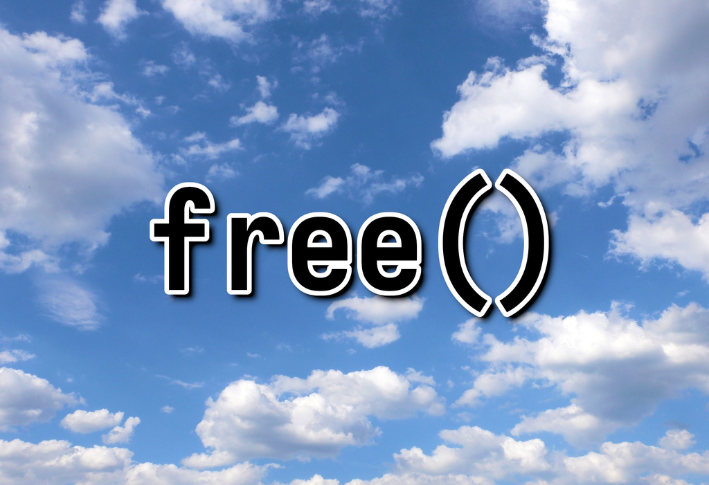

`free()` can be used to deallocate memory. It takes one parameter: a pointer to dynamically allocated memory.

For example:

```c
int *pointer = malloc(sizeof(int));
free(pointer);
```

This is all it takes to dynamically allocate memory to an integer, then deallocate it once finished using it.

> **Note:** Only use `free()` with *dynamically* allocated memory. Doing something like:

> ```c
> int x;
> free(&x);
> ```

> will result in **disastrous consequences**. You have been warned.

```c
#include <stdlib.h>

int main(void)
{
  int *pointer;
  while (1)
  {
    pointer = malloc(sizeof(int));
    free(pointer);
  }

  return 0;
}
```

This still causes an infinite loop, but at least you won’t be hogging all the memory anymore.

## `calloc()`: The Over-Accomplishing Sibling

`calloc()` is like the sibling of `malloc()` that always tries to do more. They are both related, but have differences on what they do. `calloc()` is short for “**c**ontiguous **alloc**ation,” and it will allocate memory just like `malloc()`, but also **initialize** the memory to 0, so you have no garbage values right off the bat. In this way, `calloc()` can be useful for making, for example, arrays that would have been initialized anyway.

`calloc()` takes a quantity and a size. For example:

```c
// Allocate space for 10 integers, and initialize it to 0.
int *numbers = calloc(10, sizeof(int));
```

## `realloc()`: I Changed My Mind

There is also a cousin to `malloc()`, called `realloc()`, which allows you to **re-alloc**ate memory. This can be extremely useful if you, for example, want to take an array with an initial size, but resize it later.

The basic syntax of `realloc()` is to provide a pointer to dynamically allocated memory and the new amount of memory that should be allocated. As a result, `realloc()` returns a new pointer to dynamically allocated memory. For example:

```c
// Assume "array" is already a pointer to dynamically allocated memory.
int *resized_array = realloc(array, sizeof(int) * 100);
```

You can consider the following two pieces of code to be equivalent, but notice how much shorter the version with `realloc()` is!

*Version using `malloc()` and `free()`:*

```c
// Allocate space for 10 integers
int *array = malloc(sizeof(int) * 10);

// Assume you put values in this array, and now you decided you wanted space
// for 20 integers in the array. You will need to allocate a new array, copy
// the integers from the old array to the new array, then free the old array.

int *new_array = malloc(sizeof(int) * 20);

for (int i = 0; i < 10; i++)
{
  new_array[i] = array[i];
}

free(array);

// Now we can say that "new_array" contains the same data as before, but with
// space for 20 integers instead of 10!
```

*Version using `realloc()`:*

```c
// Allocate space for 10 integers
int *array = malloc(sizeof(int) * 10);

// Assume you put values in this array, and now you decided you wanted space
// for 20 integers in the array. Let's use realloc() to combine many steps
// into a single function!

int *new_array = realloc(array, sizeof(int) * 20);
```